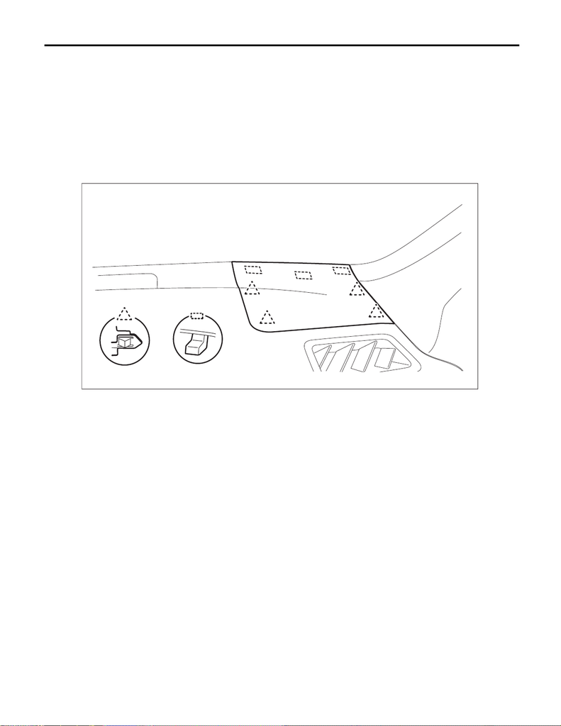

EI-85

Upper Inner Trim

EXTERIOR/INTERIOR TRIM

24.Upper Inner Trim

A: REMOVAL

CAUTION:

• Airbag system satellite safing sensor is located in the lower of the rear seat cushion center. Before

removing the rear seat, refer to “CAUTION” of “General Description” in “AIRBAG SYSTEM” section.

<Ref. to AB-9, CAUTION, General Description.>

• The airbag system is fitted with a backup power supply. After disconnecting the battery ground ca-

ble, the airbag may operate if you do not wait for 60 seconds before starting the service of airbag sys-

tem.

1) Release the clips and claws, then detach the left and right grille speaker side.

NOTE:

Remove the grille speaker side by using a plastic remover.

2) Remove the trim panel - front pillar UPR.

(1) Pull the upper part of the trim panel - front pillar UPR towards the center of the vehicle.

(2) Insert long-nose pliers into the top part of the trim, grip the tether clip with the pliers and twist 90° in

that position.

CAUTION:

Be careful not to damage the pillar trim surface and curtain airbag module when inserting the pliers.

(3) Holding the tether clip twisted as in the previous step, remove the trim panel - front pillar UPR from the

tether clip.

EI-03437

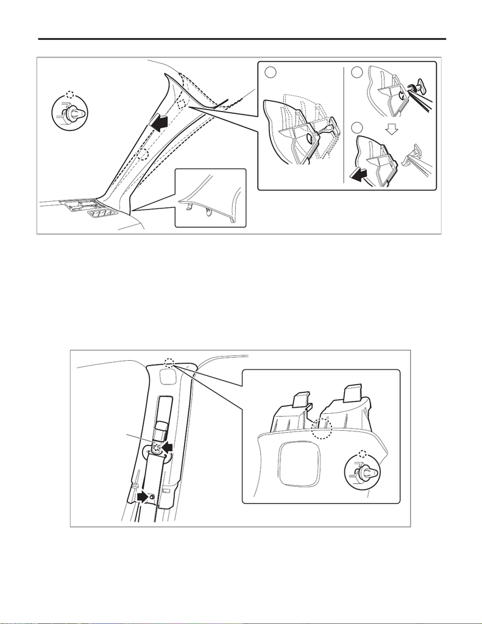

EI-86

Upper Inner Trim

EXTERIOR/INTERIOR TRIM

(4) Remove the clips, and remove the trim panel - front pillar UPR.

3) Remove the rear seat cushion assembly. <Ref. to SE-29, REMOVAL, Rear Seat.>

4) Remove the cover side sill - front INN, cover side sill - rear INN, and trim panel - center pillar LWR. <Ref.

to EI-81, REMOVAL, Lower Inner Trim.>

5) Remove the trim panel - center pillar UPR.

(1) Remove the cover through (a), and remove the seat belt anchor bolt.

(2) Remove the bolt on the lower side of the trim panel - center pillar UPR.

(3) Remove the clip by pulling the upper part of the trim toward you, and while lowering the entire trim, re-

move the trim panel - center pillar UPR.

CAUTION:

Do not reuse the upper clips of the trim panel - center pillar UPR. Once the clip is removed, its holding

force is reduced. Be sure to replace it with a new clip.

EI-03619

21

3

EI-03454

(a)

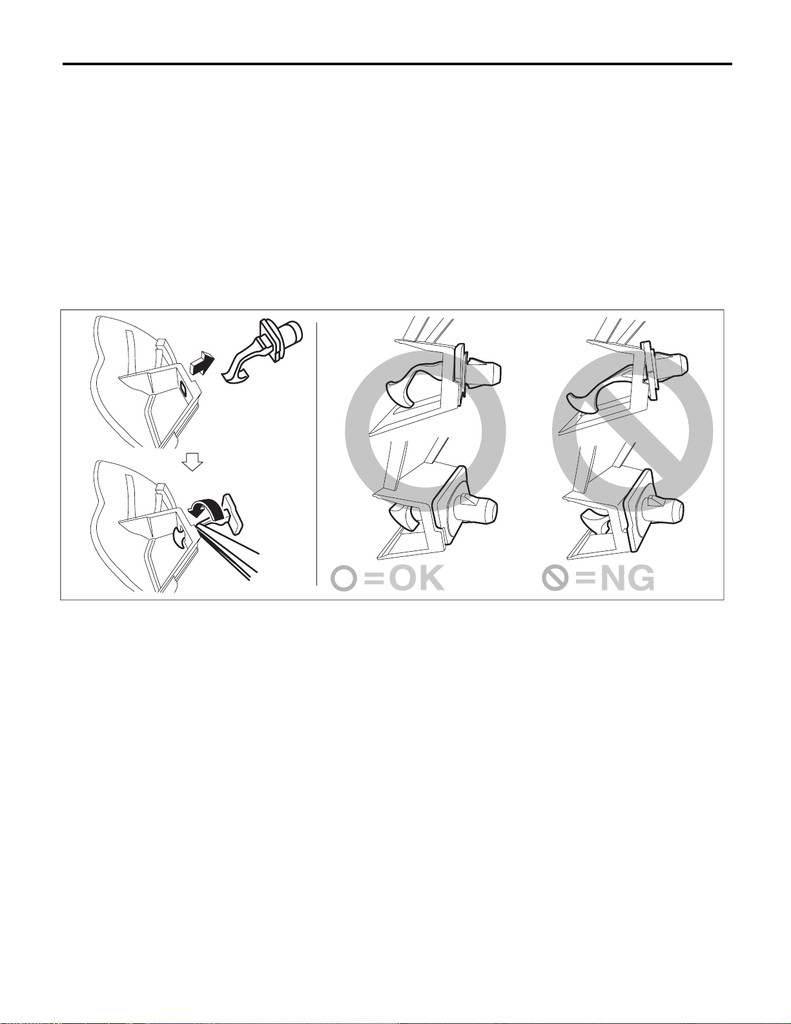

EI-87

Upper Inner Trim

EXTERIOR/INTERIOR TRIM

B: INSTALLATION

CAUTION:

front pillar UPR may come off. Be sure to replace it with a new clip.

• Do not reuse the tether clip removed from the upper part of the trim panel - front pillar UPR. Always

replace with a new part.

• Do not reuse the upper clips of the trim panel - center pillar UPR. Once the clip is removed, its hold-

ing force is reduced. Be sure to replace it with a new clip.

• Before installing the trim panel - front pillar UPR, check the condition of protective non-woven fab-

ric (white) of the curtain airbag. If it is damaged (airbag module cloth is exposed), replace the curtain

airbag module assembly with a new part.

1) Remove the remaining tether clips from the vehicle body.

2) Check the installation status of the tether clips and install the trim panel - front pillar UPR.

3) Install the trim panel - center pillar UPR.

Tightening torque:

Trim panel - center pillar UPR: 7.5 N·m (0.8 kgf-m, 5.5 ft-lb)

Front seat belt anchor: 30 N·m (3.1 kgf-m, 22.1 ft-lb)

EI-03620

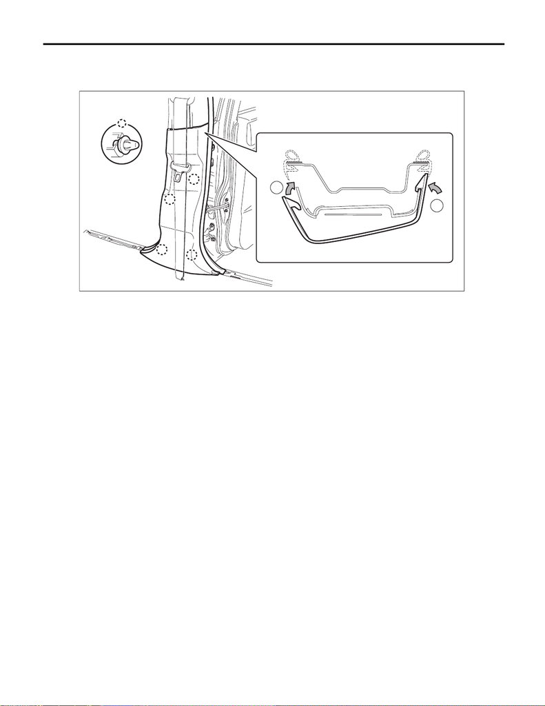

EI-88

Upper Inner Trim

EXTERIOR/INTERIOR TRIM

4) Install the trim panel - center pillar LWR, cover side sill - front INN, and cover side sill - rear INN.

NOTE:

Assemble the trim panel - center pillar LWR to the trim panel - center pillar UPR securely.

5) Install the rear seat cushion assembly.

EI-03453

1

2